# Project 2

Skyler Moomey

2020-12-09

# Abstract

# Introduction

[figure not shown]

Blackmagic Design Camera

## The Data

```r
camera_dt <- read.csv("camera_dataset.csv");
head(camera_dt[,3:4])
```

|  | Max.resolution | Low.resolution |
| --- | --- | --- |
| 1 | 1024 | 640 |
| 2 | 1280 | 640 |
| 3 | 640 | 0 |
| 4 | 1152 | 640 |
| 5 | 1152 | 640 |
| 6 | 1600 | 640 |

The data I am using come from a Kaggle dataset on 1038 different camera models, which include the variables max resolution and low-resolution settings. These variables describe the maximum resolution in pixels of a photo that a camera is capable of taking and the lowest resolution setting of the camera. My statistical hypothesis is that the maximum resolution will increase without a comparable increase in the lowest resolution of the camera software, and I will be using a SLR to determine whether there actually is a statistical relationship between the variables.

## Data Cleaning

Note: A measure of 0 pixels as a lowest resolution does not have value as a measure. If some camera has a 0 pixel lowest resolution, then no photo would be rendered. For this reason, I am removing all experimental units with a lowest resolution on file of 0 pixels, as this is probably just a stand-in value for an uncertain lowest resolution rating. Therefore, of the 1038 experimental units, only 984 will be used in my study.

## Preliminary Plots and Interpretation of the Data

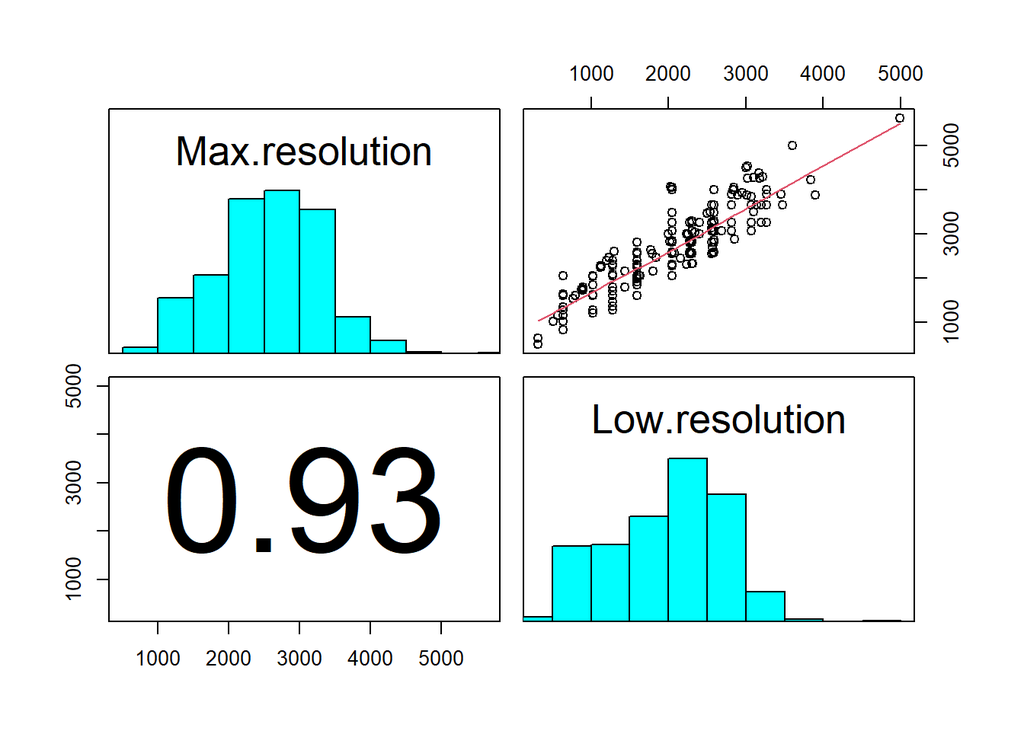

```r
library (s20x)
pairs20x(camera_dt[,3:4])

library(ggplot2)
```

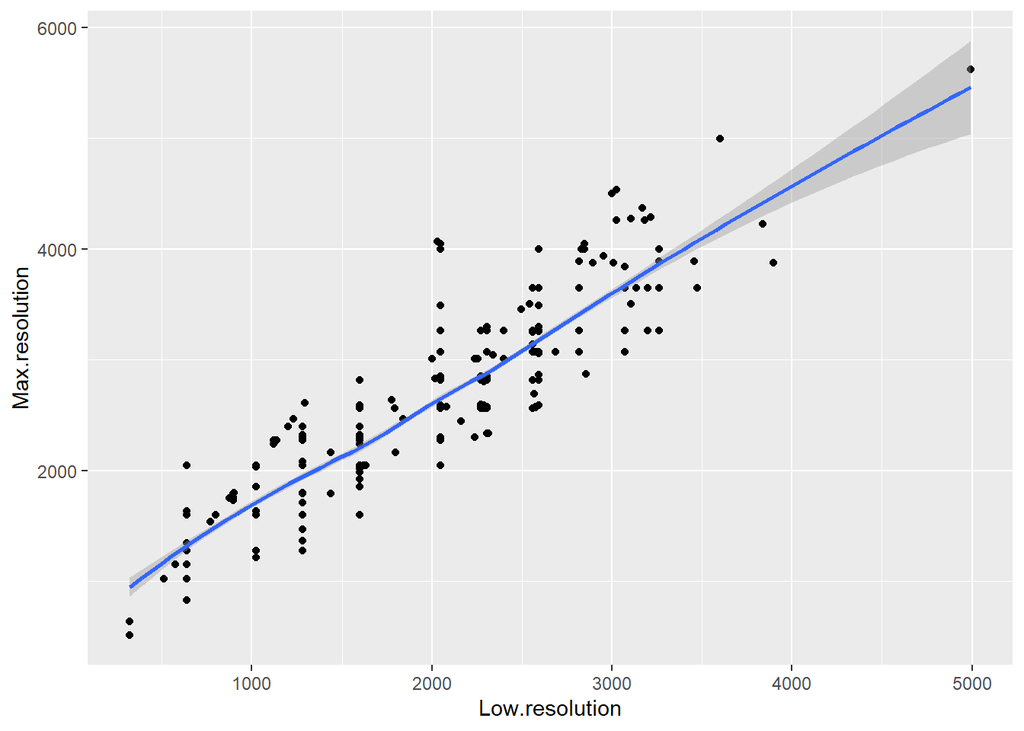

```r
g = ggplot(camera_dt, aes(y=Max.resolution, x= Low.resolution)) + geom_point()
g = g + geom_smooth(method = "loess")
g
```

Contrary to my hypothesis, it does appear that there is a linear relationship between lowest resolution setting and maximum camera resolution. The data appear to appear to have a linear correlation.

# Theoretical Basis of SLR

A Simple Linear Regression (SLR) is a predictive, probabilistic model for a sample. Since we believe a linear relationship exists between Lowest Camera Resolution setting and Maximum Camera Resolution, we can create an equation of a line to estimate values of Maximum Camera Resolution, our dependent variable. Letting $y$ represent maximum resolution and $x$ represent lowest resolution setting, we create the following equation:

Consider $y_i$, the value of a dependent variable in the sample.

We can describe $y_i$ as:

$$\begin{equation}
\begin{split}
y_i &= \beta_0 + \beta_1 x_i + \epsilon_i
\end{split}
\end{equation}$$

$$\begin{equation}
\begin{split}
E(y) = \mu_y &= E(\beta_0 + \beta_1 x_i + \epsilon_i)\\
& = E(\beta_0) + E(\beta_1 x_i) + E(\epsilon_i)\\
& = \beta_0 + \beta_1 x_i + 0 \\
& = \beta_0 + \beta_1 x_i
\end{split}
\end{equation}$$
Therefore, our equation returns the expected value of $y$ in the population for a given $x$, which is a good estimate of our sample $y$ value.

## Equation

```r
lin.mod <- with(camera_dt, lm(Max.resolution~Low.resolution))

summary(lin.mod)$coef
```

```
##                   Estimate  Std. Error  t value      Pr(>|t|)
## (Intercept)    720.1612188 23.63972763 30.46402 4.955273e-144
## Low.resolution   0.9490141  0.01175085 80.76130  0.000000e+00
```

Finally, in creating our linear model, we use the method of least squares built in to the R function lm(). This creates an equation such that error terms are minimized based on its SSR (sum of squares of residuals). The function estimates them to a $95 \%$ confidence. we find $\hat \beta_0 = 720.1612$ and $\hat \beta_1 = 0.9490$. Our p-values for both estimators are infinitesimally small, so we can assume that they are validly estimated. Our final equation is

$$\begin{equation}
y_i = 720.1612 + 0.9490 x_i
\end{equation}$$

# Assumptions

For an SLR to be a valid linear model, four assumptions about the data must be met:

## Linear Relationship

The first assumption of an SLR is that there is a linear relationship between the independent and dependent variables. As we can see based on our loess plot, there appears to be a roughly linear relationship between Low.resolution and Max.resolution. To assure ourselves of this fact, we apply a straight line to the data.

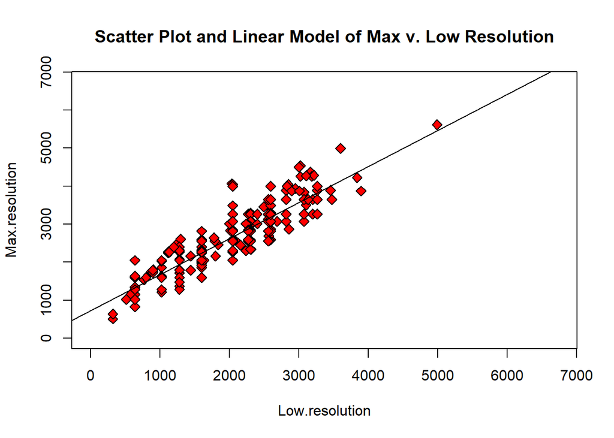

```r
with(camera_dt, plot(Max.resolution~Low.resolution, bg="Red",pch=23, cex=1.2, ylim=c(0,1.2*max(Max.resolution)), xlim=c(0,1.2*max(Max.resolution)), main="Scatter Plot and Linear Model of Max v. Low Resolution"))

lin.mod <- with(camera_dt, lm(Max.resolution~Low.resolution))
abline(lin.mod)
```

As can be seen from applying a straight to the data, it does appear that a linear relationship is present between the variables, though we will perform more analyses to determine the model’s predictive accuracy.

## Linear Independence of Residuals

The second assumption for SLR is that the residuals, that is, the error terms in a linear model, are independent. For this to be the case, there should not be a steady increase or decrease in the length of the residuals over the course of the data, which would imply that early residuals are affecting later residuals.

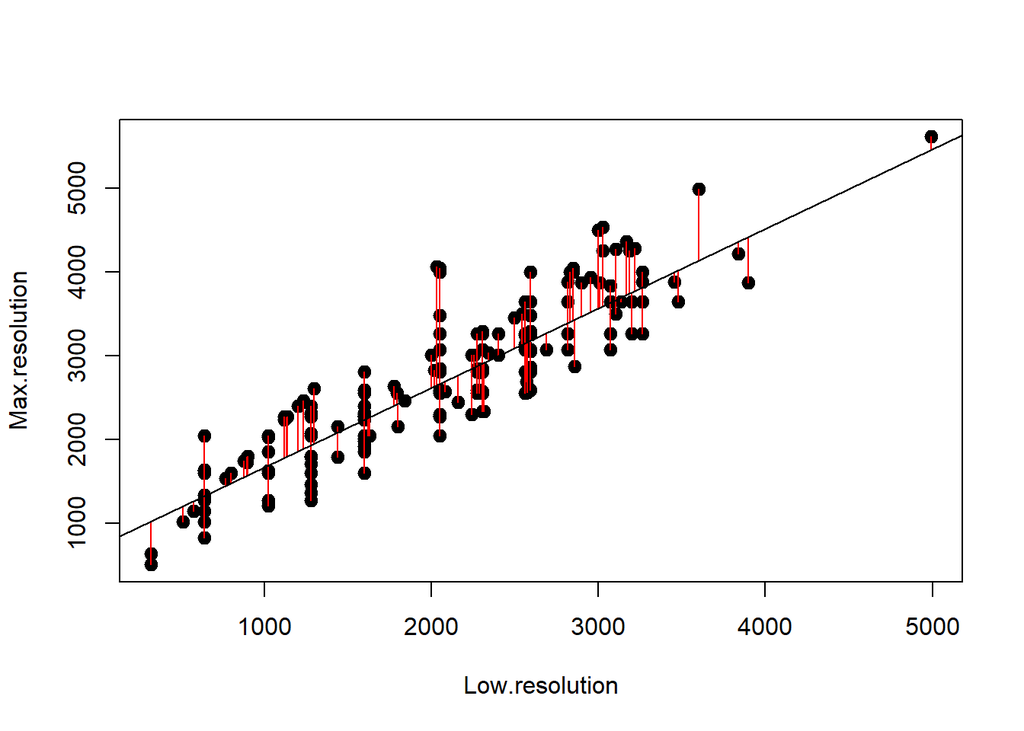

```r
with(camera_dt, plot(Max.resolution~Low.resolution,bg="black", pch=21,cex=1.2))

maxhat = with(camera_dt, predict(lin.mod, data.frame(Low.resolution)))
with(camera_dt, segments(Low.resolution, Max.resolution, Low.resolution, maxhat, col="red"))

abline(lin.mod)
```

As we can see from our graph (residuals in red), there does not seem to be a constant increase or decrease in the length of our residuals. For this reason, we can assume that they are independently distributed.

## Constant Variance (Homoscedasticity)

The third assumption that must be met for a linear model to be an accurate predictor of a population is that the residuals have a constant variance throughout the sample and be distributed around a mean of zero. This can be determined by making a graph that matches our fitted $\hat y$ estimates to the true values in the sample.

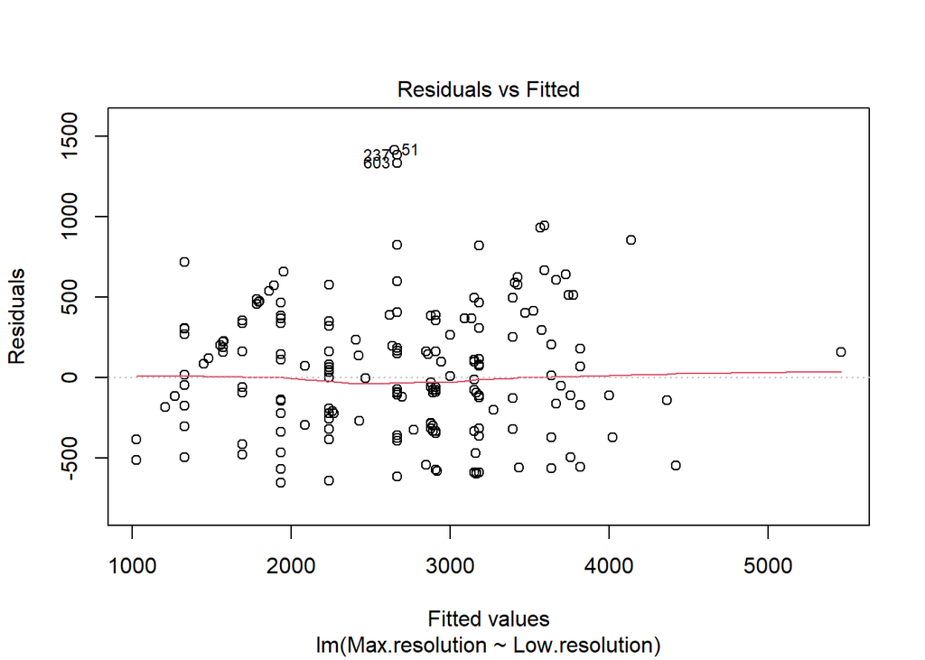

```r
plot(lin.mod, which=1)
```

As we can see from the Residuals v. Fitted plot, our errors are likely normally distributed since they seem to have an almost constant slope through the x-axis. Our linear model is supported as a model of best-fit for the data.

## Normality

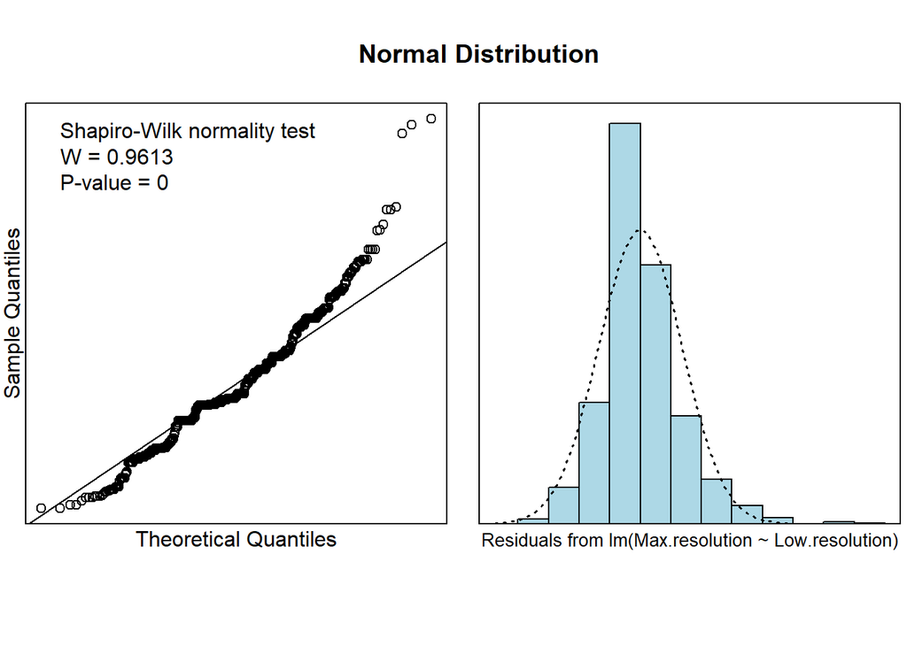

```r
normcheck(lin.mod, shapiro.wilk = TRUE)
title("Normal Distribution")
```

# Analysis of Data

## RSS

The Residual Sum of Squares can be visualized with the previous figure, that of the data points and their distance from the regression line. We represent the figure here, for convenience.

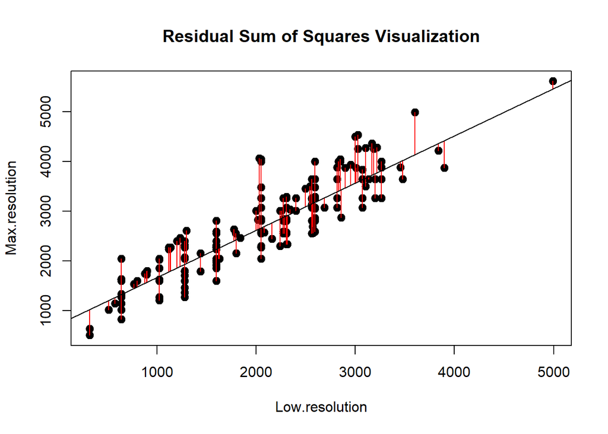

```r
res <- residuals(lin.mod)


with(camera_dt, plot(Max.resolution~Low.resolution,bg="black", pch=21,cex=1.2, main="Residual Sum of Squares Visualization"))

maxhat = with(camera_dt, predict(lin.mod, data.frame(Low.resolution)))
with(camera_dt, segments(Low.resolution, Max.resolution, Low.resolution, maxhat, col="red"))

abline(lin.mod)
```

The formula for calculating RSS is given by $RSS=\sum_{1}^{n}(y_i - \hat y_i)^2 = \sum_{1}^{n}\epsilon_i^2$. This turns out to be,

```r
RSS = with(camera_dt, sum((Max.resolution - maxhat)^2))
RSS
```

```
## [1] 72772306
```

## MSS

MSS (mean sum of squares) can be visualized as the distance of the mean of the sample $y_i's$ from the mean of the population, estimated using the linear model. It can be visualized with the following graph.

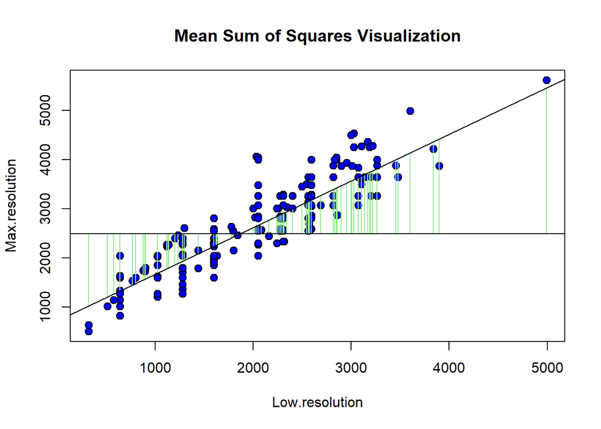

```r
with(camera_dt, plot(Max.resolution~Low.resolution,bg="blue", pch=21,cex=1.2, main="Mean Sum of Squares Visualization"))


with(camera_dt, segments(Low.resolution, mean(Max.resolution), Low.resolution, maxhat, col="light green"))

abline(lin.mod)
abline(h=mean(camera_dt$Max.resolution))
```

The value of MSS is defined to be $MSS=\sum_{1}^{n}(\bar y - \hat y)^2$. We calculate MSS for our model as,

```r
MSS = with(camera_dt, sum((maxhat - mean(Max.resolution))^2))
MSS
```

```
## [1] 483349426
```

## TSS

Finally, TSS (total sum of squares), can be visualized as the distance from each $y_i$ from $\bar y$. Graphically, it can be shown as,

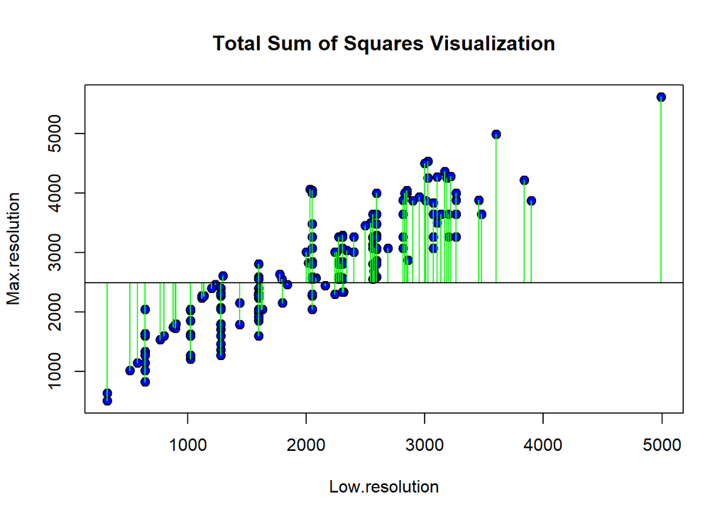

```r
with(camera_dt, plot(Max.resolution~Low.resolution,bg="blue", pch=21,cex=1.2, main="Total Sum of Squares Visualization"))

with(camera_dt, segments(Low.resolution, Max.resolution, Low.resolution, mean(Max.resolution), col="green"))

abline(h=mean(camera_dt$Max.resolution))
```

The formula for TSS is $MSS = \sum_{1}^{n}(y_i - \bar y)^2$. The value we calculate for TSS is,

```r
TSS = with(camera_dt, sum((Max.resolution - mean(Max.resolution))^2))
TSS
```

```
## [1] 556121733
```

Finally, we have everything we need to calculate $R^2$.

```r
R2=MSS/TSS
R2
```

```
## [1] 0.8691432
```

Our $R^2$ being this close to $1$ shows that our model is a very close fit to the data.

# Conclusion

Given the very probable linear relationship between maximum photo resolution and lowest resolution setting, we can assume that in camera manufacturing, the maximum resolution is positively, and linearly, correlated with the lowest resolution setting. This manufacturing choice seems odd, however. I assumed that a higher-priced and higher quality camera would allow uses the greater range in camera resolution choices. This, however, is probably not the case.

# References

https://www.kaggle.com/crawford/1000-cameras-data/ Website from which sample data were drawn.

https://www.starkinsider.com/2019/08/blackmagic-design-adds-6k-ef-mount-version-of-the-pocket-cinema-camera.html Camera photo